# A Comparative Analysis: Machine Learning

## 6.3 Stratified Train / Test Split (80 / 20)

```r
set.seed(CONFIG$seed)

trainIndex <- createDataPartition(
  ml_data$Rank_Category,
  p    = CONFIG$train_fraction,
  list = FALSE
)

train_data <- ml_data[ trainIndex, ]
test_data  <- ml_data[-trainIndex, ]

cat("Training set:", nrow(train_data), "rows\n")
```

```
## Training set: 1760 rows
```

```r
cat("Test set:    ", nrow(test_data),  "rows\n")
```

```
## Test set:     440 rows
```

```r
kable(
  data.frame(
    Class       = names(table(train_data$Rank_Category)),
    Train_Count = as.integer(table(train_data$Rank_Category)),
    Test_Count  = as.integer(table(test_data$Rank_Category))
  ),
  caption = "Class Distribution After Stratified Split"
) %>%
  kable_styling(bootstrap_options = c("striped", "hover"), full_width = FALSE)
```

Class Distribution After Stratified Split

| Class | Train_Count | Test_Count |
| --- | --- | --- |
| Others | 800 | 200 |
| Top100 | 320 | 80 |
| Top200 | 160 | 40 |
| Top500 | 480 | 120 |

**Decision:** `createDataPartition()` performs a stratified split preserving the proportion of each `Rank_Category` class in both sets. An 80/20 split gives models sufficient training data while retaining a meaningful held-out evaluation set.

## 6.4 Imputation (Training Medians Only)

```r
impute_with_train_median <- function(train_df, test_df, cols) {
  for (col in cols) {
    train_median <- median(train_df[[col]], na.rm = TRUE)
    train_df[[col]][is.na(train_df[[col]])] <- train_median
    test_df[[col]][is.na(test_df[[col]])]   <- train_median
  }
  list(train = train_df, test = test_df)
}

imputed   <- impute_with_train_median(train_data, test_data, CONFIG$predictor_cols)
train_data <- imputed$train
test_data  <- imputed$test

cat("Any NA in train_data:", anyNA(train_data), "\n")
```

```
## Any NA in train_data: FALSE
```

```r
cat("Any NA in test_data: ", anyNA(test_data),  "\n")
```

```
## Any NA in test_data:  FALSE
```

**Decision:** Imputation values were computed from the training set only and applied to both sets — this prevents data leakage from the test distribution into training.

## 6.5 Factor Conversion & Scaling

```r
train_data$Rank_Category <- as.factor(train_data$Rank_Category)
test_data$Rank_Category  <- as.factor(test_data$Rank_Category)

str(train_data)
```

```
## 'data.frame':    1760 obs. of  8 variables:
##  $ Rank_Category       : Factor w/ 4 levels "Others","Top100",..: 2 2 2 2 2 2 2 2 2 2 ...
##  $ quality_of_education: num  7 9 17 10 2 8 14 23 16 15 ...
##  $ alumni_employment   : num  9 17 11 24 29 14 31 21 52 26 ...
##  $ quality_of_faculty  : num  1 3 5 4 7 2 12 10 6 8 ...
##  $ publications        : num  1 12 4 16 37 53 14 13 6 34 ...
##  $ influence           : num  1 4 2 16 22 33 6 12 5 20 ...
##  $ citations           : num  1 4 2 11 22 26 15 14 3 28 ...
##  $ patents             : num  5 1 15 50 18 101 66 5 16 101 ...
```

```r
summary(train_data)
```

```
##  Rank_Category quality_of_education alumni_employment quality_of_faculty
##  Others:800    Min.   :  1.0        Min.   :  1.0     Min.   :  1.0
##  Top100:320    1st Qu.:173.8        1st Qu.:179.0     1st Qu.:172.0
##  Top200:160    Median :355.0        Median :448.0     Median :210.0
##  Top500:480    Mean   :275.0        Mean   :356.7     Mean   :178.1
##                3rd Qu.:367.0        3rd Qu.:478.0     3rd Qu.:218.0
##                Max.   :367.0        Max.   :567.0     Max.   :218.0
##   publications      influence       citations        patents
##  Min.   :   1.0   Min.   :  1.0   Min.   :  1.0   Min.   :  1.0
##  1st Qu.: 174.8   1st Qu.:176.0   1st Qu.:161.0   1st Qu.:176.8
##  Median : 451.0   Median :450.0   Median :406.0   Median :442.5
##  Mean   : 460.4   Mean   :459.5   Mean   :414.9   Mean   :437.7
##  3rd Qu.: 725.0   3rd Qu.:732.2   3rd Qu.:645.0   3rd Qu.:729.5
##  Max.   :1000.0   Max.   :991.0   Max.   :812.0   Max.   :871.0
```

```r
# Z-score scaling for KNN and SVM (scale-sensitive models)
preprocess_scaler <- preProcess(
  train_data[, CONFIG$predictor_cols],
  method = c("center", "scale")
)

train_scaled <- predict(preprocess_scaler, train_data[, CONFIG$predictor_cols])
test_scaled  <- predict(preprocess_scaler, test_data[, CONFIG$predictor_cols])

train_scaled$Rank_Category <- train_data$Rank_Category
test_scaled$Rank_Category  <- test_data$Rank_Category
```

## 6.6 Cross-Validation Control

```r
cv_control <- trainControl(
  method  = "repeatedcv",
  number  = CONFIG$cv_folds,
  repeats = CONFIG$cv_repeats
)
```

**Decision:** 5-fold repeated cross-validation (3 repeats) is used for hyperparameter tuning across all five models. Sharing the same `cv_control` object ensures fair, directly comparable tuning across models.

# Section 7 — Model 1: Decision Tree

## 7.1 Hyperparameter Tuning & Training

```r
set.seed(CONFIG$seed)

tree_tuned <- train(
  Rank_Category ~ .,
  data      = train_data,
  method    = "rpart",
  trControl = cv_control,
  tuneGrid  = expand.grid(cp = CONFIG$tree_cp_grid),
  control   = rpart.control(maxdepth = CONFIG$tree_maxdepth)
)

print(tree_tuned)
```

```
## CART
##
## 1760 samples
##    7 predictor
##    4 classes: 'Others', 'Top100', 'Top200', 'Top500'
##
## No pre-processing
## Resampling: Cross-Validated (5 fold, repeated 3 times)
## Summary of sample sizes: 1408, 1408, 1408, 1408, 1408, 1408, ...
## Resampling results across tuning parameters:
##
##   cp           Accuracy   Kappa
##   0.001000000  0.8596591  0.7926703
##   0.006444444  0.8575758  0.7897726
##   0.011888889  0.8500000  0.7773320
##   0.017333333  0.8454545  0.7705411
##   0.022777778  0.8386364  0.7597083
##   0.028222222  0.8263258  0.7398063
##   0.033666667  0.8100379  0.7130165
##   0.039111111  0.7986742  0.6928727
##   0.044555556  0.7973485  0.6900165
##   0.050000000  0.7973485  0.6900165
##
## Accuracy was used to select the optimal model using the largest value.
## The final value used for the model was cp = 0.001.
```

```r
cat("Best cp:", tree_tuned$bestTune$cp, "\n")
```

```
## Best cp: 0.001
```

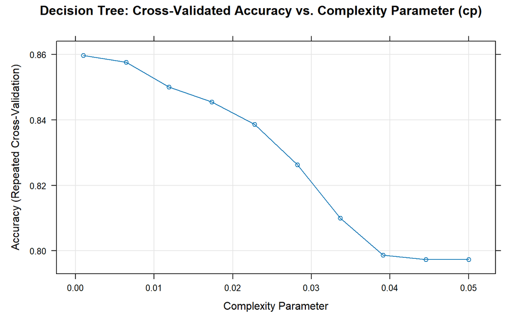

```r
plot(tree_tuned, main = "Decision Tree: Cross-Validated Accuracy vs. Complexity Parameter (cp)")
```

## 7.2 Prediction & Evaluation

```r
tree_model      <- tree_tuned$finalModel
tree_prediction <- predict(tree_tuned, newdata = test_data)
tree_cm         <- confusionMatrix(tree_prediction, test_data$Rank_Category)
print(tree_cm)
```

```
## Confusion Matrix and Statistics
##
##           Reference
## Prediction Others Top100 Top200 Top500
##     Others    184      0      0     22
##     Top100      0     66      2      0
##     Top200      0     13     29      8
##     Top500     16      1      9     90
##
## Overall Statistics
##
##                Accuracy : 0.8386
##                  95% CI : (0.8009, 0.8718)
##     No Information Rate : 0.4545
##     P-Value [Acc > NIR] : < 2.2e-16
##
##                   Kappa : 0.7616
##
##  Mcnemar's Test P-Value : NA
##
## Statistics by Class:
##
##                      Class: Others Class: Top100 Class: Top200 Class: Top500
## Sensitivity                 0.9200        0.8250       0.72500        0.7500
## Specificity                 0.9083        0.9944       0.94750        0.9187
## Pos Pred Value              0.8932        0.9706       0.58000        0.7759
## Neg Pred Value              0.9316        0.9624       0.97179        0.9074
## Prevalence                  0.4545        0.1818       0.09091        0.2727
## Detection Rate              0.4182        0.1500       0.06591        0.2045
## Detection Prevalence        0.4682        0.1545       0.11364        0.2636
## Balanced Accuracy           0.9142        0.9097       0.83625        0.8344
```

## 7.3 Tree Visualisation — Style 1

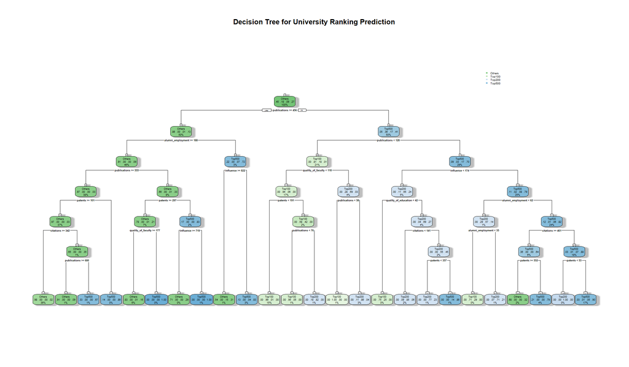

```r
rpart.plot(
  tree_model,
  type          = 2,
  extra         = 104,
  fallen.leaves = TRUE,
  box.palette   = "GnBu",
  shadow.col    = "gray",
  nn            = TRUE,
  main          = "Decision Tree for University Ranking Prediction"
)
```

## 7.4 Tree Visualisation — Style 2

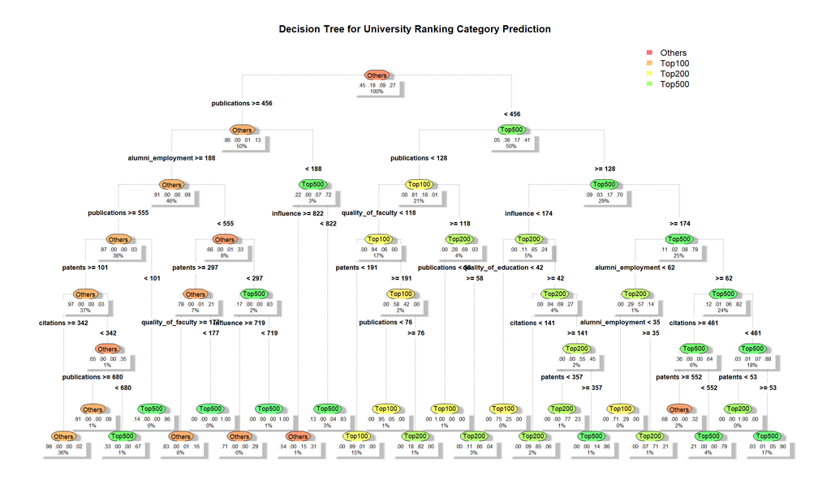

```r
rpart.plot(
  tree_model,
  type        = 4,
  extra       = 104,
  under       = TRUE,
  faclen      = 0,
  varlen      = 0,
  tweak       = 1.2,
  shadow.col  = "gray",
  box.palette = "RdYlGn",
  branch.lty  = 3,
  main        = "Decision Tree for University Ranking Category Prediction"
)
```

## 7.5 Feature Importance

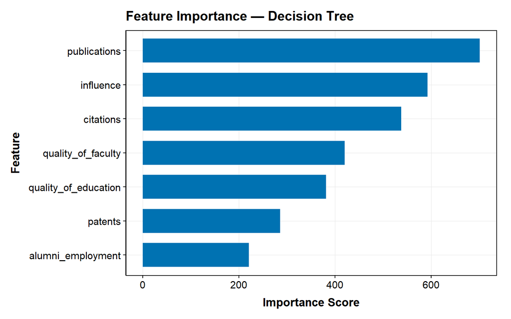

```r
tree_importance    <- tree_model$variable.importance
tree_importance_df <- data.frame(
  Feature    = names(tree_importance),
  Importance = as.numeric(tree_importance)
)

ggplot(tree_importance_df,
       aes(x = reorder(Feature, Importance), y = Importance)) +
  geom_col(fill = PUB_PALETTE[1], width = 0.7) +
  coord_flip() +
  labs(title = "Feature Importance — Decision Tree",
       x = "Feature", y = "Importance Score") +
  theme_pub()
```